# Sheet 10

## Flow Matching

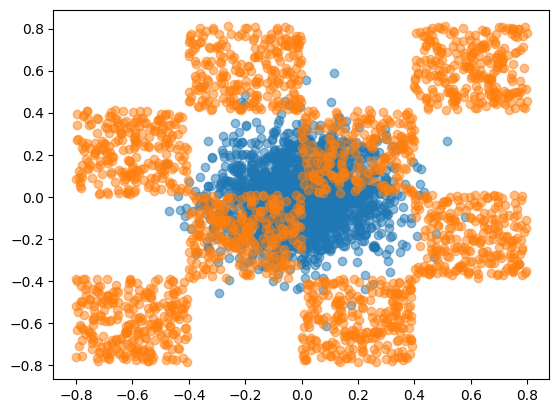

```python
import torch
import matplotlib.pyplot as plt


def generate_checkerboard_sample(num_samples=10, field_size=0.4, num_fields=2, center=True):
    x = torch.rand(num_samples, 2) * field_size
    offset = torch.randint(0, num_fields, (num_samples, 2)) * field_size * 2
    diagonal_shift = torch.randint(0, num_fields, (num_samples, 1)) * field_size
    x += offset + diagonal_shift

    if center:
        x -= torch.mean(x, dim=0)

    return x

base_distribution_std = 0.15
num_samples = 2000
x = torch.randn(num_samples, 2) * base_distribution_std
y = generate_checkerboard_sample(num_samples=num_samples)

# show points
plt.scatter(x[:, 0], x[:, 1], alpha=0.5, label='base distribution')
plt.scatter(y[:, 0], y[:, 1], alpha=0.5, label='checkerboard distribution')
plt.show()
```

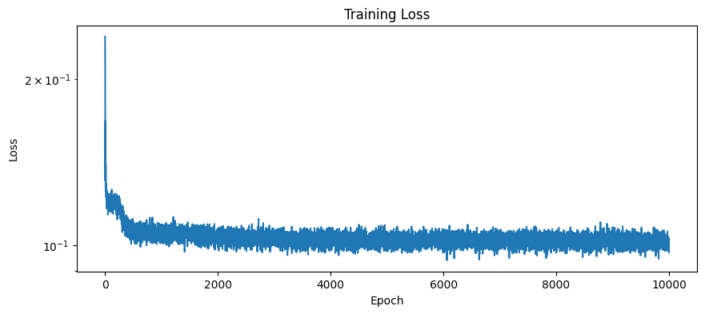

```python
# define a model
from torchvision.ops import MLP
from tqdm import tqdm

device = "cuda" if torch.cuda.is_available() else "cpu"

model = MLP(in_channels=2 + 1, hidden_channels=[512, 512, 512, 512, 2], activation_layer=torch.nn.SiLU)
model.to(device)

# define a loss function
criterion = torch.nn.MSELoss(reduction="none")

# define an optimizer
optimizer = torch.optim.Adam(model.parameters(), lr=0.001)


# train the model:
num_epochs =  10000
batch_size = 4096
losses = []
for epoch in tqdm(range(num_epochs)):
    x = torch.randn(batch_size, 2) * base_distribution_std
    y = generate_checkerboard_sample(num_samples=batch_size)

    # Sample random times t from [0, 1]
    t = torch.rand(batch_size, 1).to(device)

    # Interpolate between x and y: z_t = (1 - t) * x + t * y
    z_t = (1 - t) * x.to(device) + t * y.to(device)

    # Compute the target velocity: v_t = y - x
    v_target = (y - x).to(device)

    # Concatenate z_t and t to create model input
    model_input = torch.cat([z_t, t], dim=1)

    # Forward pass: predict velocity
    v_pred = model(model_input)

    # Compute loss
    loss = criterion(v_pred, v_target).mean()

    # Backward pass
    optimizer.zero_grad()
    loss.backward()
    optimizer.step()

    losses.append(loss.item())

# Plot training losses
plt.figure(figsize=(10, 4))
plt.plot(losses)
plt.xlabel('Epoch')
plt.ylabel('Loss')
plt.title('Training Loss')
plt.yscale('log')
plt.show()
```

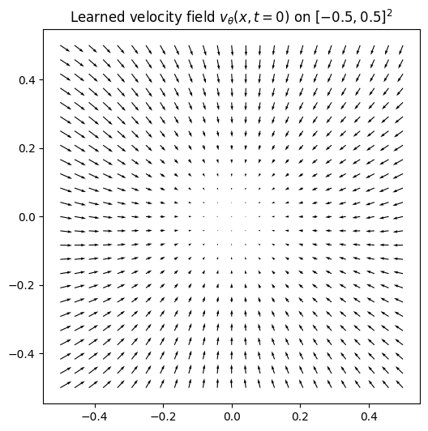

```python
model.eval()

# 1) build grid in [-0.5, 0.5]^2
grid_lim = 0.5
n = 25  # resolution
xs = torch.linspace(-grid_lim, grid_lim, n)
ys = torch.linspace(-grid_lim, grid_lim, n)
X, Y = torch.meshgrid(xs, ys, indexing="xy")

pts = torch.stack([X.reshape(-1), Y.reshape(-1)], dim=1).to(device)  # (n*n, 2)

# 2) evaluate v_theta(x, t=0)
t0 = torch.zeros(pts.shape[0], 1, device=device)

with torch.no_grad():
    v = model(torch.cat([pts, t0], dim=1)).cpu()   # (n*n, 2)

U = v[:, 0].reshape(n, n)
V = v[:, 1].reshape(n, n)

# 3) quiver plot
plt.figure(figsize=(6, 6))
plt.quiver(X, Y, U, V)
plt.title("Learned velocity field $v_\\theta(x, t=0)$ on $[-0.5,0.5]^2$")
plt.axis("equal")
plt.show()
```

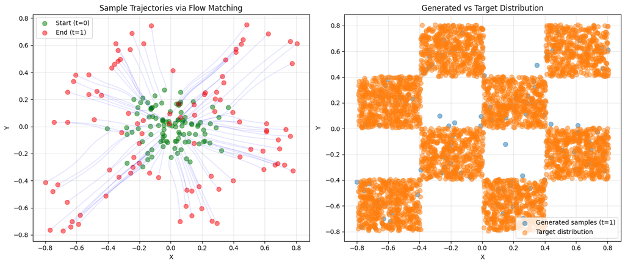

```python
# Run inference with the trained model
# Use Euler integration scheme with 100 steps to integrate the velocity field
import numpy as np
model.eval()

# Generate starting samples from base distribution
num_inference_samples = 100
z = torch.randn(num_inference_samples, 2) * base_distribution_std
z = z.to(device)

# Store trajectories for visualization
trajectories = [z.clone().detach().cpu()]

# Euler integration from t=0 to t=1 with 100 steps
num_steps = 100
dt = 1.0 / num_steps

with torch.no_grad():
    for step in range(num_steps):
        # Current time
        t = (step / num_steps) * torch.ones(num_inference_samples, 1).to(device)

        # Create model input: concatenate position and time
        model_input = torch.cat([z, t], dim=1)

        # Predict velocity
        v = model(model_input)

        # Euler step: z_{n+1} = z_n + dt * v
        z = z + dt * v

        # Store trajectory
        trajectories.append(z.clone().detach().cpu())

# Convert trajectories to numpy for plotting
trajectories = [traj.numpy() for traj in trajectories]

# Plot the trajectories
fig, axes = plt.subplots(1, 2, figsize=(14, 6))

# Plot 1: Trajectories
ax = axes[0]
for i in range(num_inference_samples):
    traj = [trajectories[step][i] for step in range(len(trajectories))]
    traj = np.array(traj)
    ax.plot(traj[:, 0], traj[:, 1], alpha=0.1, color='blue')

ax.scatter(trajectories[0][:, 0], trajectories[0][:, 1], alpha=0.5, label='Start (t=0)', s=50, color='green')
ax.scatter(trajectories[-1][:, 0], trajectories[-1][:, 1], alpha=0.5, label='End (t=1)', s=50, color='red')
ax.set_xlabel('X')
ax.set_ylabel('Y')
ax.set_title('Sample Trajectories via Flow Matching')
ax.legend()
ax.grid(True, alpha=0.3)

# Plot 2: Comparison of final distribution with target
ax = axes[1]
ax.scatter(trajectories[-1][:, 0], trajectories[-1][:, 1], alpha=0.5, label='Generated samples (t=1)', s=50)
ax.scatter(y[:, 0].numpy(), y[:, 1].numpy(), alpha=0.5, label='Target distribution', s=50)
ax.set_xlabel('X')
ax.set_ylabel('Y')
ax.set_title('Generated vs Target Distribution')
ax.legend()
ax.grid(True, alpha=0.3)

plt.tight_layout()
plt.show()
```

Interpretations:

### (c) Why can this $t=0$ field be suboptimal? How does minibatch optimal transport help?

Flow matching aims to produce integration trajectories that are as straight as possible.  
However, the field from (b) is essentially a global-mean field:

- $v^*(x,0)=\mu_q-x$ initially pushes almost all points toward a single global mean.
- Later, trajectories must split to reach different checkerboard modes.
- This introduces curvature and potentially crossing trajectories, making paths less straight.

Minibatch optimal transport mitigates this because it does not pair $x_0$ with an independent random $x_1$. Instead, within each minibatch it computes an OT coupling that minimizes transport cost:

- Each $x_0$ is matched to a more “appropriate” $x_1$.
- Then the target direction $x_1-x_0$ depends more on $x_0$ and points toward a local target mode rather than the global mean.